# Assignment 3

## Submit as an HTML file

Print your Emory ID below

```python
print(2672070)
```

```
2672070
```

Import the numpy and matplotlib packages

```python
import numpy as np
import matplotlib.pyplot as plt
```

(a) Compute a formula:

The formula for the volume of a cone is:

$V = \frac{1}{3} \pi r^2 h$

Where:

- $V$ is the volume of the cone
- $r$ is the radius of the base
- $h$ is the height of the cone

Calculate $V$ when:

- $r = 5$
- $h = 10$

To get full points:

- First define each of these variables
- Write the formula above
- Print out the result

```python
# variables
r = 5
h = 10
pi = np.pi

v = (1/3) * np.pi * r**2 * h

print(v)
```

```
261.79938779914943
```

(b) Composite operations on arrays

- Define r = 0.1
- Define x = 1
- Define two arrays $A$ and $T$ using "np.array()", assigning the following values

$ a = \begin{pmatrix} a_1 \\ a_2 \\ a_3 \end{pmatrix} = \begin{pmatrix} 28 \\ 32 \\ 11 \end{pmatrix}, \qquad t = \begin{pmatrix} t_1 \\ t_2 \\ t_3 \end{pmatrix} = \begin{pmatrix} 4 \\ 5 \\ 6 \end{pmatrix} $

- Use element-by-element vector operations to compute a new array $M$ of length 3:

$ M = \begin{pmatrix} a_1 \cdot (1+r)^{t_1} + cos(x) \\ a_2 \cdot (1+r)^{t_2} + cos(x) \\ a_3 \cdot (1+r)^{t_3} + cos(x) \end{pmatrix} $

- Compute the sum of the values of $M$ using "M.sum()"

Note: I am using subscripts to denote the individual elements of $a$ and $t$.

- In the code just enter the values of $a$ and $t$.
- To get full points you must do all of the above tasks

```python
# variables
r = .1
x = 1

# arrays
a = np.array([28,32,11])
t= np.array([4,5,6])

M = np.array([a * (1+ r)** t + np.cos(x)])
sum =  M.sum()

print(sum)
print(M)
```

```
113.63919791760446
[[41.53510231 52.07662231 20.02747331]]
```

(c) Plot a normal random variable

To get full points:

- Set a seed using "np.random.seed()"
- Create the random variable with the following parameters
- mean = 233, standard deviation = 99, and size = 1314
- Create a histogram
- Label the axes

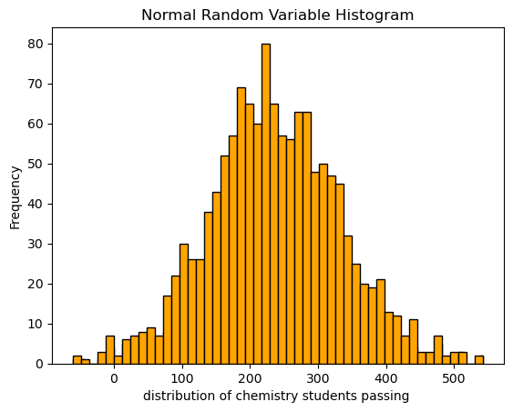

```python
np.random.seed(56)

# noraml variables

mean = 233
stdv = 99
size = 1314


random_variable = np.random.normal(loc=mean, scale=stdv, size=size)

# Create a histogram
plt.hist(random_variable, bins=100, edgecolor='black')

# Label the axes
plt.ylabel('Frequency')
plt.hist(x = random_variable, color="orange", bins = 50, edgecolor = "black")
plt.title("Normal Random Variable Histogram")
plt.xlabel("distribution of chemistry students passing ")
plt.show()
```

(d) Checking whether word is part of list

- Define a variable "QSS" with the value "Statistics"
- Define a list of fruits with the values list_QSS = ["Statistics", "CS", "Dara Science", "Math"]
- Write an expression to test whether "QSS" is contained in "list_QSS"

Hint: Use the "in" command. The final output should be True/False.

To get full points run all of the above commands

```python
# variables
today = "Portguese"
QSS = "Statistics"
list_QSS = ["Statistics","CS","Data Science","Math"]

print('CS' in list_QSS)
print(today in list_QSS)
```

```
True
False
```

(e) Classifying a variable

- Define a new variable "film_score" and assign it "70"
- Write an if/else statement that does the following
  - print("Box-office Success") if the score is strictly above 80.
  - print("Intermediate Range") if the score is weakly less than 80 and strictly above 20.
  - print("Box-office Failure") if the score does not fit in the above categories.

To get full points you must do all of the above instructions

```python
# Variables
film_score = 70
if film_score > 80:
    print("Box Office Success")
elif film_score >20:
    print("Intermediate Range")
else:
    print("Box Office Failure")
```

```
Intermediate Range
```